# Introduction to Scientific Programming in Python

## Lecture 1

# For the Course, You Need:

- A laptop computer with **Python 3** installed
- The following Python packages installed (taken care of if Anaconda was installed):
  - **NumPy** (import numpy)
  - **Pandas** (import pandas)
  - **Scipy** (import scipy)
  - **Matplotlib** (import matplotlib)
- **IPython** and **Jupyter Notebook** should be installed

# Course Expectations

By the end of the course, you should:

- be familiar with core programming concepts and approaches to solving problems.
- be familiar with the core tools in python for performing scientific analysis.
- be comfortable discovering and using new python packages beyond the core tools.

## Course Plan

- **Weeks 1-2**: Core Python Review and Intro to IPython and Jupyter Notebook
- **Weeks 3-4**: Building Matrices in NumPy
- **Weeks 5-6**: Reading Data Files and Plotting in Matplotlib
- **Weeks 7-8**: Building DataFrames and Plotting in Pandas and Seaborn
- **Week 9**: Statistics in Scipy Stats
- **Week 10**: Review and Group Presentations

Reach Goals: Statistical Modeling in statsmodels, psych stimulus experiments in PsychoPy

# What is Python?

## Python is a General-Purpose Scripting Language

```python
print('In fact, this presentation is being run in Python!')
a = 3 + 2
Image(url='https://upload.wikimedia.org/wikipedia/commons/thumb/c/c3/Python-logo-notext.svg/1024px-Python-logo-notext.svg.png',
     width=200)

print(a)
```

```
In fact, this presentation is being run in Python!
5
```

## General Purpose

- Quicker Learning: Easy to Perform Different Tasks in the Same Environment
- Code Complexity doesn't change when your task changes

## Scripting Language

- Code compiles down to additional intermediate programming languages before running.
- Makes code easier to read, often at the cost of performance.
- Human Time is often more valuable than Computer Time
- CPython vs Jython vs PyPy

# Quick Aside: Python vs Matlab

(For More info, please see http://www.pyzo.org/_images/pythonvsmatlab.png)

```python
Image(url='http://www.pyzo.org/_images/pythonvsmatlab.png',
      width=1000)
```

[figure not shown]

# Scientific Programming Exercise

Scientific Programming is the combined set of tasks that scientists must perform to analyze and understand their data. This includes, but is not limited to:

- Accessing Data
- Transforming Data
- Statistical Analysis of Data
- Plotting Data
- Creating Figures for Publication

**Take Home Message**: Scientific Programming is all about **scientific data**.

# Informal Class Poll: Raise Your Hand If:

## You are a Bachelor's Student.

```python
education_level = {'bachelor': 0,
                   'master': 2,
                   'phd': 10,
                   'postdoc': 4}
```

## Your laptop is running Windows.

```python
operating_system = {'windows': 10,
                    'mac': 10,
                    'linux': 3}
```

## Your Lab Uses Python

```python
lab_languages = {'python': 16,
                 'matlab': 20,
                 'r': 6,
                 'julia': 1,
                 'other': 2}
```

## You Have Experience in Python.

```python
languages = {'python': 5,
             'matlab': 10,
             'r': 2,
             'julia': 0,
             'other': 2}
```

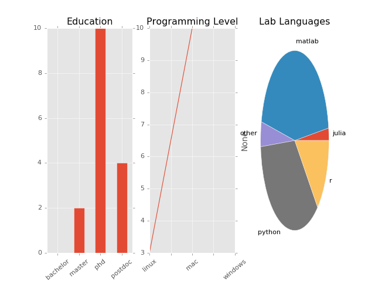

```python
plot_class_poll()
```

# Development Tools: IPython and Jupyter Notebook

# IPython ("Interactive Python")

IPython is a Full-Featured interactive console for Python.

```python
HTML('<iframe src="https://ipython.org/ipython-doc/2/interactive/tutorial.html" width=900 height=500></iframe>')
```

[interactive chart not shown]

# The Notebook (aka IPython Notebook, Jupyter Notebook)

```python
Image(url='http://jupyter.org/assets/jupyterpreview.png', width=800)
```

[figure not shown]

## Notebook Exercise:

1. Open a Notebook in Jupyter in a new folder on your computer.
2. Change the Title of the Notebook
3. Make an integer variable and a string variable in the first cell
4. Print the output of multiplying the two variables together
5. Add a markdown cell above the cell you just made, and make a Header title
6. Create an interactive console session with the **%qtconsole** magic.

## Markdown CheatSheet

```python
HTML('<iframe src="https://github.com/adam-p/markdown-here/wiki/Markdown-Cheatsheet" width=900 height=500></iframe>')
```

[interactive chart not shown]

# Python Variables and Variable Types

```python
a_int = 3
a_float = 4.4
a_bool = True
a_str = 'hello'
a_list = [1, 2.4, 'goodbye']
a_tuple = (4, 3.5, 'dog', 'cat')
a_dict = {1: 5, 'a': 2, 'b': 'cat', 'dog': 8}
a_set = {1, 1, 2}
```

```python
type(a_str)
```

```
str
```

## All **Instances** of **Types** can be formed with a **Constructor**

```python
b_int = int(3)
b_float = float(6.3)
b_str = str('hi')
b_list = list([1, 2, 3])
b_tuple = tuple([1,2,3])

c_int = int(b_float)
```

```python
s = int('5')
s
```

```
5
```

## Operators (ex: +, -, /, * ) Do Different Things to Different Types

```python
3 + 5
```

```
8
```

```python
7 / 2.6
```

```
2.692307692307692
```

```python
print('Hi' * 5)
['Hi'] * 5
```

```
HiHiHiHiHi
```

```
['Hi', 'Hi', 'Hi', 'Hi', 'Hi']
```

# Advanced Features

## Tuple Unpacking

```python
a, (b, c) = (1, (3, 5))
a, b = b, a
a, b
```

```
(3, 1)
```

## Assignment with Operators

```python
a = 5
a = a + 2
a
```

[output not shown]

# Bool Rules: 0 and Empty are False, all else are True

```python
bool(3)
bool(-4.2)
bool("")
bool(['a', 'b', 'c'])
```

```
True
```

```python
bool(0)
bool(0.0)
bool('')
bool([])
```

```
False
```

# Python is an "Object-Oriented" Language

```python
print(dir('helo'))
```

```
['__add__', '__class__', '__contains__', '__delattr__', '__dir__', '__doc__', '__eq__', '__format__', '__ge__', '__getattribute__', '__getitem__', '__getnewargs__', '__gt__', '__hash__', '__init__', '__iter__', '__le__', '__len__', '__lt__', '__mod__', '__mul__', '__ne__', '__new__', '__reduce__', '…
```

# Python is a "Dynamically Typed" Language

- This means that, unlike in other languages, you can change the type of a variable at any time you wish.
- To check that a variable is a certain type, use the **isinstance()** function or compare types directly

```python
a = 3
print(  isinstance(a, str)   )
print(  type('Hello') == str  )
```

```
False
True
```

## Exercise: Find the Type of variable obtained from dividing an int by a float

# More OOP Jargon

- **Class** is the **type** of a variable.
- **Instance** is a **constructed** variable of that class.
  - Often, people will call the instance an **object**, although this isn't technically correct.
- **Attribute** or **Property** is data that belongs to an object.
  - In Python, this is accessed via the **dot (.)**
  - ex) my_float.real
- **Method** is a **Function** that belongs to an object.
  - In Python, you **call** functions with the **parentheses**.
  - ex) 'Hello'.upper()

### In Python, Everything is an Object (to be explored)

# Read the Documentation!

To understand what an object can do and how to use it, you have many possible sources of information:

1. The Package's Documentation itself.
2. The **help()** function
3. In IPython, the ?.
   - Ex) sorted?
4. In IPython, the Tab button after the dot.
5. The **dir()** function.

# Essential String Methods

```python
example_string = 'Mary had a little lamb named Sue.'
big_string = example_string.upper()
```

```python
example_string.upper()
```

```
'MARY HAD A LITTLE LAMB NAMED SUE.'
```

```python
example_string.find('a', 2, 5)
```

```
-1
```

### 5-Min Exercise: Find Out What the following methods do, and how to use them!

```python
print( example_string.capitalize() )
example_string = example_string.replace('a', 'T')
print(example_string)
example_string.count
example_string.isalpha
example_string.isdigit
example_string.islower
print(example_string.split(' '))
'/'.join(['a', 'cat', 'is'])
```

[output not shown]

```
'a/cat/is'
```

# Essential List Methods

```python
example_list = ['Python', 'Science', 'Awesome']

new_list = example_list.reverse()
print(new_list)
example_list.append
example_list.extend
example_list.sort
example_list.remove
example_list.pop
example_list.count
```

```
None
```

```
<function list.count>
```

# Homework

1. Finish Codeacademy Tutorial!
2. Get Everything running on your Laptop

Extra Challenge: http://www.codewars.com

This Script can be Downloaded at https://github.com/neuroneuro15/SciPyCourse2016

# Quick Review

- What are some good reasons to use Python?
- How do you find out what **class** a variable belongs to?
- How do you get more information about an object?

# Extra Exploration: "Everything is an Object"

```python
import math
type(math)
```

```
module
```

```python
a = 3
type(3)
```

```
int
```

```python
type(max)
```

```
builtin_function_or_method
```

```python
type(int)
```

```
type
```

```python
type(type)
```

```
type
```